# git pull upstream master

# Answer questions from the previous session

# Why optimization ?

[Chandler Carruth talk @ CppCon 2015](https://www.youtube.com/watch?v=nXaxk27zwlk)

[video not shown]

# Algorithmic ideas

- Complexity: quantifies the computation needs
- How to multiply two numbers a and b: a * 111
  - $\underbrace{a + a + ... + a}_{111~times}$
- Multiplication strategy learned at school: $a \cdot 100 + a \cdot 10 + a \cdot 1$
- In binary: $$4 \cdot 3 = 100 \cdot 11 = 100 << 1 + 100 << 0 = 1000 + 100 = 1100 = 2^3 + 2^2 = 8 + 4 = 12$$
- The efficiency of an algorithm is much more important than the technology/harware used to execute it.
  - Exemple of series $\sum_k^N k = N(N+1)/2$
  - The complexity of the naive algorithm to compute a N-body problem is $O(N^2)$

# Code optimization

# Compiler optimization option

- In order to ask the compiler, one should ask for compilation with optimization.

```
gcc -c file.cc -O3
```

- while for debugging the compiler should be required to attach debugging symbols

```
gcc -c file.cc -g
```

In CLion, you can get this option with the Configuration menu in the CMake settings.

Let's try this:

```
int foo(const int &i) { return i + 18; }

int main() {

  unsigned long res = 0;
  for (long i = 1; i < 1000000000; ++i) {
    res += i + foo(i);
  }
  std::cout << "Hello, World! " << res << std::endl;
  return 0;
}
```

# GNU profiler

There are several tools to profile a code which aims at helping the optimization process.

- The GNU profiler: gprof. You need to compile the sources with an option to GCC.

```
g++ -c -pg file.cc -g
g++ -pg -o program_name file.o
```

To use it in CLion, you should add the following in your CMakeLists.txt

```
set(CMAKE_CXX_FLAGS "-pg")
set(SOURCE_FILES main.cpp test.cpp)
```

Then you launch your program normally and a file gmon.out will be produced which can be analysed with the program *gprof*.

```
gprof PROGRAM_NAME gmon.out
```

For a line by line information you can use:

```
gprof -l PROGRAM_NAME gmon.out
```

# Valgrind & Cachegrind

- Valgrind: running your program through valgrind can allow to profile the call graph

```
valgrind --tool=callgrind PROGRAM_NAME arguments
```

- A file is created: *callgrind.out.pid*
- It can be analyzed with kcachegrind (only under Unix-like OS, sorry).

# [Perf Tool](https://perf.wiki.kernel.org/index.php/Main_Page)

- Instruments CPU performance counters
- Lightweight profiling
- Included in the Linux kernel, under tools/perf
- Frequently updated and enhanced

```
perf record -g program
perf report -G
```

[Chandler Carruth talk @ CppCon 2015](https://www.youtube.com/watch?v=nXaxk27zwlk)

# C/C++: code optimization

Presenting the basic rules to get optimization on standard CPUs

# What is a function call ?

```
double foo(const int &a) { return a + 1.5; }
```

## At the assembly level => overhead

- Saving the context
- Copying the arguments
- jump to another block of instruction (GO TO)
- copy the result
- restore context

# Inline functions

```
inline double foo(const int &a) { return a + 1.5; }

int main() {
  int sz = 1000000;
  std::vector<double> res;
  res.resize(sz);

  for (int i = 0; i < sz; ++i) {
    // since it is inlined there is no actual function call
    res[i] = foo(i);
  }
}
```

# Virtual table and calls

- Virtual table (virtual method table, virtual function table, virtual call table, dispatch table, or vtable, VMT or Vtable)
- Mechanism supporting dynamic dispatch (or run-time method binding)
- Compilers add a hidden pointer to the virtual method to call table
- Concretely a VMT is an array of pointers to (virtual) functions

Consider the following:

```
struct ComputeInterface {
  virtual double compute() = 0;
};

struct A : public ComputeInterface {
  virtual double compute() { return M_PI; };
};

struct B : public ComputeInterface {
  virtual double compute() { return M_E; };
};
```

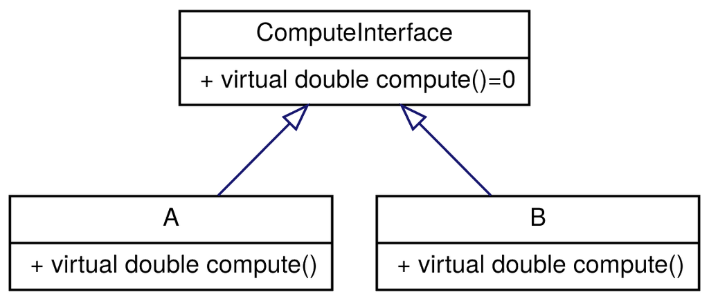

If we manipulate objects with the mother class type e.g.:

```
double performCompute(ComputeInterface &compute) { return compute.compute(); }

int main() {
  A a;
  performCompute(a);
  B b;
  performCompute(b);
}
```

With the virtual table:

```
double computeMethodA(ComputeInterface * _this){return M_PI;};
double computeMethodB(ComputeInterface * _this){return exp(1.);};

struct ComputeInterface { FunctionPointer computeMethodPtr; };

double performCompute(ComputeInterface * compute){
  return compute->computeMethodPtr(compute);
}
```

With the following call

```
void main(){
  ComputeInterface a;
  a.computeMethodPtr = computeMethodA; performCompute(&a);
  ComputeInterface b;
  b.computeMethodPtr = computeMethodB; performCompute(&b);
}
```

The most dramatic effect of virtual function calls is that it prevents (in most cases) the possibility to inline.

This should be avoided in the **critical loops**

## On the critical loops

Scientific codes have large loops $\Rightarrow$ The **critical loops**

```
  for (unsigned int a = 0; a < nb_atoms; ++a) {
    // do something for every atoms...
  }
```

- When possible, decisions should be avoided in critical loops

```
  for (unsigned int a = 0; a < nb_atoms; ++a) {
    if (a % 2 == 0) {
      // do something ...
    } else {
      // do something else...
    }
    // generate an execution flow divergence
  }
```

- Virtual calls should also be avoided in critical loops

# About memory localization

- The processor reads memory by chunks: pre-fetch of information in [memory cache](https://en.wikipedia.org/wiki/CPU_cache)
- Contiguous data access optimizes *cache fill* and avoids [cache misses](https://en.wikipedia.org/wiki/CPU_cache#Cache_miss)
- **In general, ordered memory accesses are more efficient than random memory accesses**

# Templates

# Some more factorization ?

- Some algorithms are not *type dependent*

```
int getMaximum(const int &a, const int &b) {
  if (a > b)
    return a;
  return b;
}
```

```
double getMaximum(const double &a, const double &b) {
  if (a > b)
    return a;
  return b;
}
```

## Can we use **types** as **parameters** ?

# Template Functions

```
template<typename T>
T getMaximum(const T & a, const T & b) {
  if (a > b)
    return a;
  return b;
}
```

```
template<typename T>
T getMaximum(const T & a, const T & b) {
  if (a > b)
    return a;
  return b;
}
```

```
template<typename T>
T getMaximum(const T & a, const T & b) {
  if (a > b)
    return a;
  return b;
}
```

# Type matching !

```
  double a,b;
  double res_d = getMaximum(a,b);
```

or

```
  int c,d;
  int res_i = getMaximum(c,d);
```

# Apply templates to a vector class ?

# Yes

# Template Classes

```
template <typename T> class MyVector {
public:
  T &operator[](unsigned int dim) { return value[dim]; }

private:
  T value[3];
};
```

```
template <typename T> class MyVector {
public:
  T &operator[](unsigned int dim) { return value[dim]; }

private:
  T value[3];
};
```

```
template <typename T> class MyVector {
public:
  T &operator[](unsigned int dim) { return value[dim]; }

private:
  T value[3];
};
```

```
template <typename T> class MyVector {
public:
  T &operator[](unsigned int dim) { return value[dim]; }

private:
  T value[3];
};
```

```
template <typename T> class MyVector {
public:
  T &operator[](unsigned int dim) { return value[dim]; }

private:
  T value[3];
};
```

# Template Classes

- MyVector is a templated class
- Template parameters included in type definition

```
MyVector<double> real_vector;
MyVector<int> integer_vector;
```

- Will be done during compilation
- Instanciated Template classes/functions: modified name (*MyVectorInt*, *MyVectorDouble*)

Template parameters can be:

```
- Other types (typename)
- Integers
- Enum values
```

## Templates: Adding dimension to the vector type

```
template <typename T, int dim = 3> class MyVector {
```

...

```
  T value[dim];
};
```

```
template <typename T, int dim = 3> class MyVector {
```

...

```
  T value[dim];
};
```

Using it:

```
MyVector<double> vector_3d;
MyVector<double, 2> vector_2d;
```

# Type Matching: scalar product function

```
T scalarProduct(const MyVector &v1, const MyVector &v2) {

  T res;
  for (int d = 0; d < dim; ++d)
    res += v1[d] * v2[d];
  return res;
}
```

Using:

```
  MyVector<double> vector1_3d;
  MyVector<double> vector2_3d;

  double res = scalarProduct(vector1_3d, vector2_3d);
  std::cout << res << std::endl;
```

```
template <typename T> T getMaximum(const T &a, const T &b) {
  if (a > b)
    return a;
  return b;
}
```

**getMaximum** working over vectors ?

```
  MyVector<double> v1, v2;
  MyVector<double> res = getMaximum(v1, v2);
```

# Template specialization

- Exceptions in type matching

```
template <>
MyVector<double, 3>
getMaximum<MyVector<double, 3>>(const MyVector<double, 3> &v1,
                                const MyVector<double, 3> &v2) {

  MyVector<double, 3> max;
  for (int i = 0; i < 3; ++i) {
    max[i] = getMaximum(v1[i], v2[i]);
  }
  return max;
}
```

# Template specialization

- Exceptions in type matching

```
template <>

MyVector<double, 3>
getMaximum<MyVector<double, 3>>(const MyVector<double, 3> &v1,
                                const MyVector<double, 3> &v2) {

  MyVector<double, 3> max;
  for (int i = 0; i < 3; ++i) {
    max[i] = getMaximum(v1[i], v2[i]);
  }
  return max;
}
```

# Template specialization

- Exceptions in type matching

```
template <>
MyVector<double, 3>
getMaximum<MyVector<double, 3>>(const MyVector<double, 3> &v1,
                                const MyVector<double, 3> &v2) {

  MyVector<double, 3> max;
  for (int i = 0; i < 3; ++i) {
    max[i] = getMaximum(v1[i], v2[i]);
  }
  return max;
}
```

```
  MyVector<double> v1, v2;
  MyVector<double> res = getMaximum(v1, v2);
```

# Templates specialization

- Can we code-factor more ?

```
template <typename T, int dim>
MyVector<T, dim> getMaximum(const MyVector<T, dim> &v1,
                            const MyVector<T, dim> &v2) {

  MyVector<T, dim> max;
  for (int i = 0; i < dim; ++i) {
    max[i] = getMaximum(v1[i], v2[i]);
  }
  return max;
}
```

This is overloading

# Template meta programming

```
int arithmetic(int i) {
  if (i == 1)
    return 1;
  return i + arithmetic(i - 1);
}
```

Let's call the function

```
  int a = 5;
  std::cout << arithmetic(a);
  std::cout << std::endl;
```

```
template <int i> int arithmetic_template() {
  return i + arithmetic_template<i - 1>();
}

template <> int arithmetic_template<1>() {
  // ends recursion
  return 1;
}
```

## Let's call the function

```
  std::cout << arithmetic_template<5>();
```

# Can we do this ?

```
  int a = 5;
  std::cout << arithmetic_template<a>();
  std::cout << std::endl;
```

And why ?

# Variadic template meta programming

```
template <typename T> T adder(T v) { return v; }

template <typename T, typename... Args>
// template ...Args is a variadic template
T adder(T first, Args... args) {
  return first + adder(args...);
}
```

Using it simply

```
  std::cout << adder(1, 2, 3, 4);
  std::cout << adder(1., 2, 3., 4);
  std::cout << adder(std::string("a"), std::string("b"));
```

# Take away message

- **Templating** is a mechanism to **substitute** parameters during compilation
- **Template Classes** create types with parameters included in the type name
- **Template parameters** are other types, integers, enums
- Compiler does **type matching** to deduce template parameters
- **Specializations** allow exceptions
- **Overloading** or **Template** ? no rule: need programming experience
- **Meta-programming** allows calculation at compilation
- **Variadic templates** allow flexible expressions

# About Functors and Lambdas

```
struct MyFunctor {
  int operator()() { return 2; }
};

int main() {
  auto f = MyFunctor();
  std::cout << f() << std::endl;
}
```

```
struct MyFunctor {
  inline int operator()() { return a; }
  int a;
};

int main() {
  auto f = MyFunctor();
  int a = 2;
  f.a = a;

  for (int i = 0; i < 100000; ++i) {
    auto res = f();
  }
}
```

```
struct MyFunctor {
  inline int operator()() { return *a; }
  int *a;
};

template <typename T> void loop(T f) {
  for (int i = 0; i < 100000; ++i) {
    auto res = f();
  }
}

int main() {
  auto f = MyFunctor();
  int a = 2;
  f.a = &a;
  loop(f);
}
```

# Lambda function

http://fr.cppreference.com/w/cpp/language/lambda

```
template <typename T> void loop(T f) {
  for (int i = 0; i < 100000; ++i) {
    auto res = f();
  }
}

int main() {
  int a = 2;
  loop([&a]() { return a; });
}
```

# Implementation of std::for_each

```
template <typename Vec, typename T> void for_each(Vec &vec, T f) {
  for (auto &v : vec) {
    auto res = f(v);
  }
}

int main() {
  int a = 2;
  std::vector<double> v(10000);
  for_each(v, [&a](auto &v) { return a; });
}
```